# MSDS 6306 - Live Session Unit 04 Assignment

Dmitry Andreev

February 7, 2018

## Question 1 - FiveThirtyEight Data

This question asks us to clone the eighteenth data set from the ‘fivethirtyeight’ package, assign it to a dataframe object, provide the URL to the new story related to this data set, and lastly use several R commands to get an understanding of the dataframe structure.

1. Install the fivethirtyeight package

```r
installed.packages("fivethirtyeight")
```

```
##      Package LibPath Version Priority Depends Imports LinkingTo Suggests
##      Enhances License License_is_FOSS License_restricts_use OS_type Archs
##      MD5sum NeedsCompilation Built
```

2. Assign eighteenth data set from fivethirtyeight package to an object called ‘df’.

```r
library(fivethirtyeight)
df <- data.frame(college_recent_grads)
```

3. Use a more detailed list of the data sets to write out the URL in a comment to the related news strory.

```r
vignette("fivethirtyeight", package = "fivethirtyeight")
```

```
## starting httpd help server ... done
```

```r
# The eighteenth data set in the package is titled "The Economic Guide to Picking a College Major"
# by Ben Casselman published on 09/12/2014
# https://fivethirtyeight.com/features/the-economic-guide-to-picking-a-college-major/
```

3. Use R command(s), give the dimensions and column names of this data frame.

```r
# Apply the dim() function to obtain the dimensions of the df data frame
dim(df)
```

```
## [1] 173  21
```

```r
# Apply the colnames() function to output the columns name of the df data frame
colnames(df)
```

```
##  [1] "rank"                        "major_code"
##  [3] "major"                       "major_category"
##  [5] "total"                       "sample_size"
##  [7] "men"                         "women"
##  [9] "sharewomen"                  "employed"
## [11] "employed_fulltime"           "employed_parttime"
## [13] "employed_fulltime_yearround" "unemployed"
## [15] "unemployment_rate"           "p25th"
## [17] "median"                      "p75th"
## [19] "college_jobs"                "non_college_jobs"
## [21] "low_wage_jobs"
```

## Question 2 - Data Summary

This question asks us to perform several procedures to the newly assigned data frame labelled df from Question 1 as outlined below:

1. Write an R command that gives the column names and another command that counts the number of columns but not rows of the data frame.

```r
# Apply the colnames() function to output the columns name of the df data frame
colnames(df)
```

```
##  [1] "rank"                        "major_code"
##  [3] "major"                       "major_category"
##  [5] "total"                       "sample_size"
##  [7] "men"                         "women"
##  [9] "sharewomen"                  "employed"
## [11] "employed_fulltime"           "employed_parttime"
## [13] "employed_fulltime_yearround" "unemployed"
## [15] "unemployment_rate"           "p25th"
## [17] "median"                      "p75th"
## [19] "college_jobs"                "non_college_jobs"
## [21] "low_wage_jobs"
```

```r
# Apply the ncol() function to output the number of columns for the df data frame
ncol(df)
```

```
## [1] 21
```

2. Generate a frequency count for each major_category in the data frame.

```r
# Load the plyr library
library(plyr)

# Apply the count function to the df data frame for the major_category column and assign it to a variable
# named major_count
major_count <- count(df, "major_category")
major_count
```

```
##                         major_category freq
## 1      Agriculture & Natural Resources   10
## 2                                 Arts    8
## 3               Biology & Life Science   14
## 4                             Business   13
## 5          Communications & Journalism    4
## 6              Computers & Mathematics   11
## 7                            Education   16
## 8                          Engineering   29
## 9                               Health   12
## 10           Humanities & Liberal Arts   15
## 11 Industrial Arts & Consumer Services    7
## 12                   Interdisciplinary    1
## 13                 Law & Public Policy    5
## 14                   Physical Sciences   10
## 15            Psychology & Social Work    9
## 16                      Social Science    9
```

```r
# Check the class of the major_count variable to make sure it's a data frame
class(major_count)
```

```
## [1] "data.frame"
```

3. Make a barplot of the major_count variable.

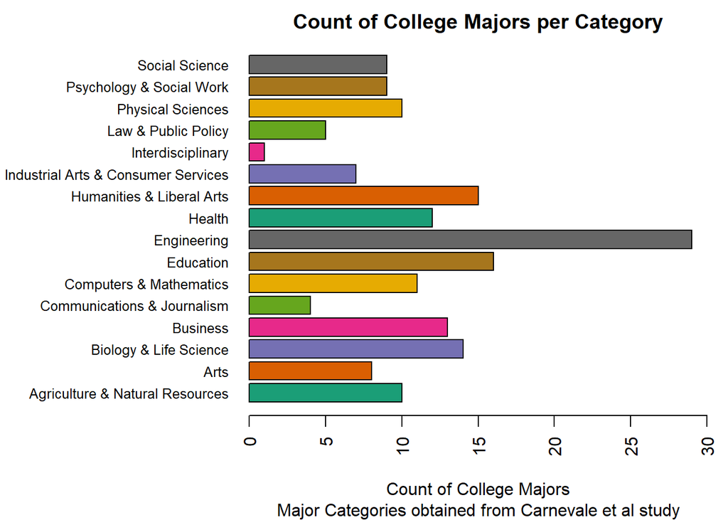

```r
# Load the RColorBrewer library to create a more visually appealing plot
library("RColorBrewer")

# Use the par() function to make label text perpendicular to the axes and to increase the left margin
# space to make it easier to read the labels
par(las = 2)
par(mar = c(5, 12, 2, 1))

# Use barplot() function to create barplot per requirements listed in question description
barplot(major_count$freq,
        names = major_count$major_category,
        main = 'Count of College Majors per Category',
        sub = "Major Categories obtained from Carnevale et al study",
        xlab = "Count of College Majors",
        xlim = c(0, 30),
        col = brewer.pal(n = 8, name = "Dark2"),
        cex.names = 0.8,
        horiz = TRUE)
```

3. Write the fivethirtyeight data frame to a csv file.

```r
# Check the current working directory
getwd()
```

```
## [1] "C:/Users/Dmitr/Desktop/MSDS 6306 - 402/Unit 4/Homework"
```

```r
# Set working directory to MSDS 6306 homework #4 folder on local machine
setwd("C:/Users/Dmitr/Desktop/MSDS 6306 - 402/Unit 4/Homework")

# Write the fivethirtyeight data frame to a csv file, excludid row labels, in MSDS 6306 homework #4 folder
# on local machine
write.csv(df, "C:/Users/Dmitr/Desktop/MSDS 6306 - 402/Unit 4/Homework/recent-grads.csv", row.names = FALSE)
```

## Question 3 - Codebook

This question asks use to create a new GitHub repository to store MSDS 6306 homework, create README.md files for the root directory and any individual assignment folders, and lastly post the RMarkdown script along with the resulting HTML file and associated fivethirtyeight .csv file and website link to the GitHub repo.

1. Start a new repositroy on GitHub for MSDS 6306 homework. On your local device, make sure there is a directory for MSDS 6306 homework.
   - New GitHub repository was created via Google Chrome browser
   - New folders created on local machine using Windows browser

```r
# Create folder labeled Homework within MSDS 6306 folder on local machine and set as working directory
setwd("C:/Users/Dmitr/Desktop/MSDS 6306 - 402/Homework")
```

2. Create README.md file which explains purpose of repository for root directory as well as in folders for individual assignments.
   - README.md files created using Windows Notepad and will be pushed to GitHub repo using Gitbash
3. In one of the nested directories, post RMarkdown script, HTML file, and fivethirtyeight .csv file for homework #4 assignment.
   - Required files were saved in MSDS 6306 homework #4 folder
   - Use GitBash to push local MSDSD 6306 homework folder to GitHub repo

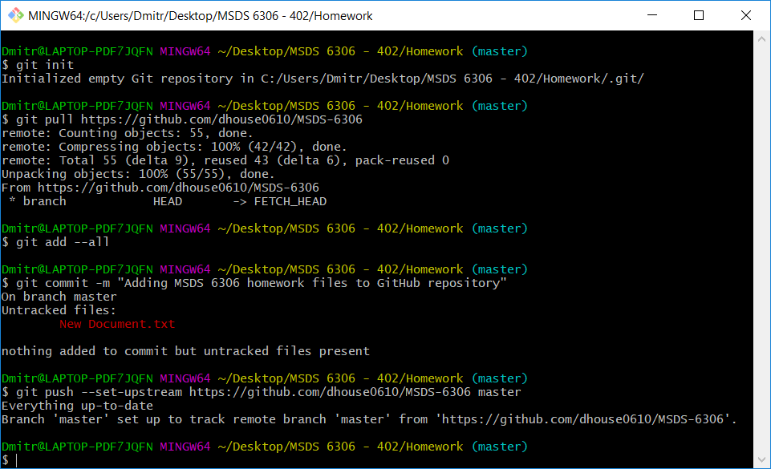

4. Provide link to MSDS 6306 GitHub homework repository.
   - https://github.com/dhouse0610/MSDS-6306